# Mini Project 1

A Scatter plot with LOESS smooth shows where every runner is a point, with a smooth trend line. Times rise slowly until the 50s, then climb faster. The widespread at older ages indicates higher variability. I chose method = “loess”, locally estimated scatterplot smoothing because the relationship between age and finish time is nonlinear, and times increase slowly until the 50s, then accelerate. LOESS adapts to local patterns without imposing a global parametric form.In the scatter plot, geom_smooth(se = TRUE) shows uncertainty with confidence bands. Finally, axis padding was controlled with expand = expansion() to align segments at zero. Together, these components make the visualizations readable, reproducible, and professional.

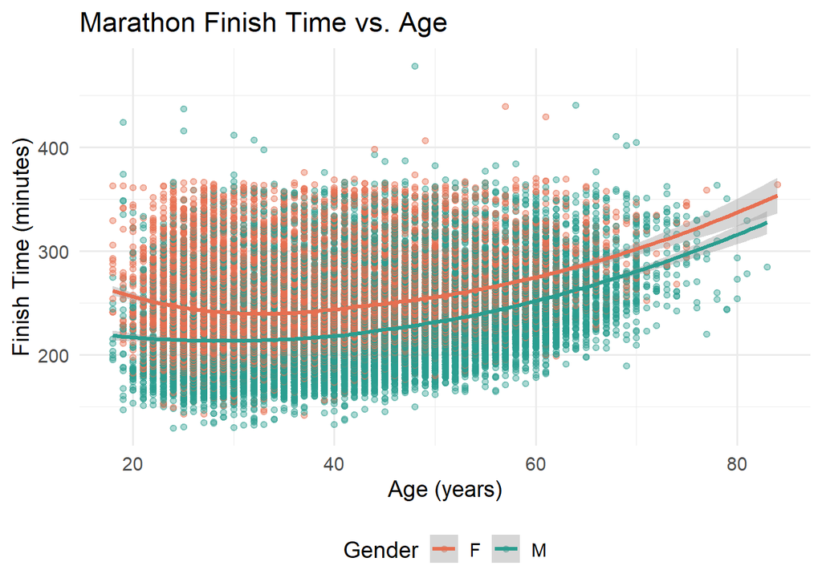

```r
# Scatter plot: Age vs. Finish Time
ggplot(df, aes(x = age, y = time_min, color = gender)) +
  geom_point(alpha = 0.4, size = 1.5) +
  geom_smooth(method = "loess", se = TRUE, size = 1.2) +
  scale_color_manual(values = c("M" = "#2A9D8F", "F" = "#E76F51")) +
  labs(title = "Marathon Finish Time vs. Age",
       x = "Age (years)", y = "Finish Time (minutes)", color = "Gender") +
  theme_minimal(base_size = 14) +
  theme(legend.position = "bottom")
```

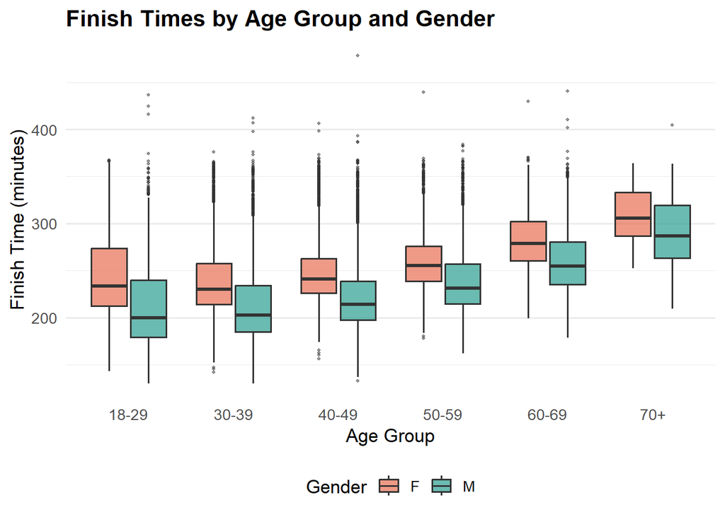

```r
# Boxplot: Finish time by age group and gender
ggplot(df, aes(x = age_group, y = time_min, fill = gender)) +
  geom_boxplot(outlier.size = 0.8, outlier.alpha = 0.5, alpha = 0.7) +
  scale_fill_manual(values = c("M" = "#2A9D8F", "F" = "#E76F51")) +
  labs(title = "Finish Times by Age Group and Gender",
       x = "Age Group", y = "Finish Time (minutes)", fill = "Gender") +
  theme_minimal(base_size = 13) +
  theme(panel.grid.major.x = element_blank(),
        legend.position = "bottom",
        plot.title = element_text(face = "bold"))
```

```r
outlier_summary <- df %>%
  group_by(age_group, gender) %>%
  mutate(
    Q1 = quantile(time_min, 0.25, na.rm = TRUE),
    Q3 = quantile(time_min, 0.75, na.rm = TRUE),
    IQR = Q3 - Q1,
    is_outlier = time_min < (Q1 - 1.5*IQR) | time_min > (Q3 + 1.5*IQR)
  ) %>%
  summarise(
    total_runners = n(),
    outlier_count = sum(is_outlier, na.rm = TRUE),
    outlier_pct = round(100 * outlier_count / total_runners, 1),
    .groups = "drop"
  )
```

Additionally, I created a Raincloud Plotcombining a half violin (density shape), a boxplot (summary), and jittered points (every runner). I had to use Using ggdist::stat_halfeye to create this visualization that communicates skewness, multimodality, and individual spread better than any other. The raincloud plot uses position_dodge(width = 0.8) for the half violin and boxplot to align them side by side per age group, while position_jitterdodge() adds random horizontal noise to the raw points so they don’t overlap each other or the summary elements, preserving the ability to see every runner while keeping the dodge alignment. I chose the raincloud plot because it combines three views—density shape (half‑violin), summary statistics (boxplot), and every individual runner, jittered points, into one graphic. This reveals skewness, multimodality, and spread better than any single chart type.I wasnted to include the violin plot to see if non normal distributions existed with outliers.

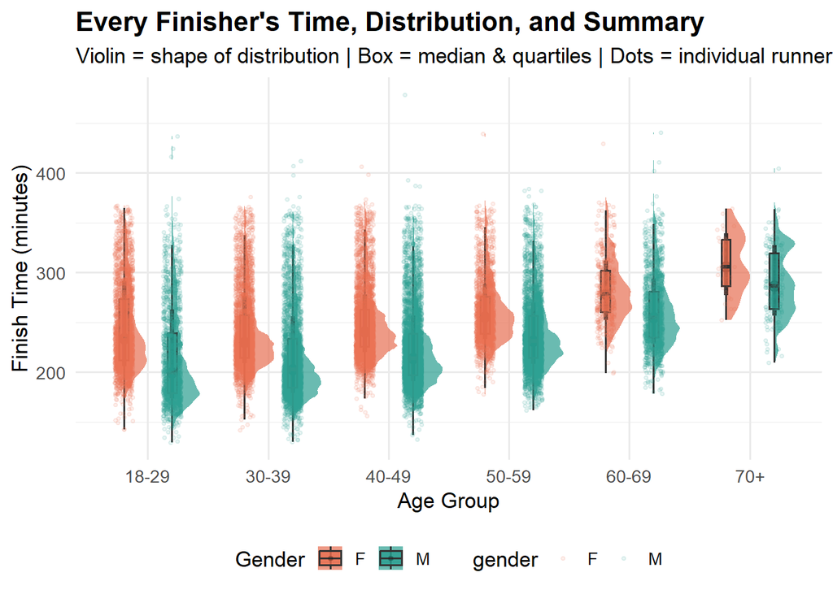

```r
# Full distribution (violin), Summary statistics (boxplot), Every runner (jittered points)
ggplot(df, aes(x = age_group, y = time_min, fill = gender)) +
  stat_halfeye(adjust = 0.5, width = 0.6, alpha = 0.7,
               position = position_dodge(width = 0.8)) +
  geom_boxplot(width = 0.15, outlier.shape = NA, alpha = 0.8,
               position = position_dodge(width = 0.8)) +
  geom_point(aes(color = gender), alpha = 0.1, size = 0.8,
             position = position_jitterdodge(jitter.width = 0.3,
                                             dodge.width = 0.8)) +
  scale_fill_manual(values = c("M" = "#2A9D8F", "F" = "#E76F51")) +
  scale_color_manual(values = c("M" = "#2A9D8F", "F" = "#E76F51")) +
  labs(title = "Every Finisher's Time, Distribution, and Summary",
       subtitle = "Violin = shape of distribution | Box = median & quartiles | Dots = individual runners",
       x = "Age Group", y = "Finish Time (minutes)", fill = "Gender") +
  theme_minimal(base_size = 13) +
  theme(legend.position = "bottom",
        plot.title = element_text(face = "bold", size = 16))
```

The raincloud plot shows the visual interaction (men and women’s distributions across age groups). This test gives you the statistical proof that the interaction is real.

```r
# Two-way ANOVA: gender, age_group, and their interaction
aov_interaction <- aov(time_min ~ gender * age_group, data = df)
summary(aov_interaction)
```

```
##                     Df   Sum Sq Mean Sq  F value   Pr(>F)
## gender               1  2665265 2665265 1778.800  < 2e-16 ***
## age_group            5  4648448  929690  620.476  < 2e-16 ***
## gender:age_group     5    47327    9465    6.317 7.23e-06 ***
## Residuals        26398 39553449    1498
## ---
## Signif. codes:  0 '***' 0.001 '**' 0.01 '*' 0.05 '.' 0.1 ' ' 1
```

```r
# Calculate mean finish times for each gender-age combination
interaction_means <- df %>%
  group_by(gender, age_group) %>%
  summarise(
    mean_time = round(mean(time_min, na.rm = TRUE), 1),
    .groups = "drop"
  )

# Show the means table
interaction_means
```

```
## # A tibble: 12 × 3
##    gender age_group mean_time
##    <chr>  <fct>         <dbl>
##  1 F      18-29          245.
##  2 F      30-39          240.
##  3 F      40-49          249.
##  4 F      50-59          261.
##  5 F      60-69          282.
##  6 F      70+            308.
##  7 M      18-29          214.
##  8 M      30-39          215.
##  9 M      40-49          224.
## 10 M      50-59          239.
## 11 M      60-69          261.
## 12 M      70+            290.
```